# 36-315 Homework 03, Fall 2016

# Problem 4

(3 points each)

**Bar Charts at the Proportion and Percentage Scales**

```r
library(data.table)
library(ggplot2)
bike_data <- fread("https://raw.githubusercontent.com/sventura/315-code-and-datasets/master/data/nyc-citi-bike-data-subset.csv")
dim(bike_data)
```

```
## [1] 4359   16
```

1. The graphs are the same.

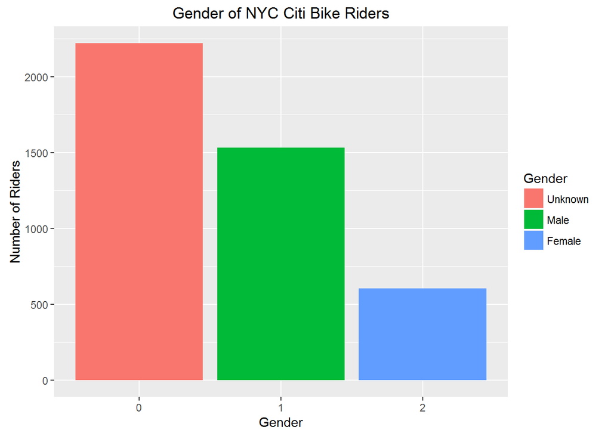

```r
ggplot(data = bike_data, aes(x = gender)) +
  geom_bar(aes(y = ..count.., fill = gender)) +
  labs(x = "Gender", y = "Number of Riders") +
  ggtitle("Gender of NYC Citi Bike Riders") +
  scale_fill_discrete(name = "Gender", labels = c("Unknown", "Male", "Female"))
```

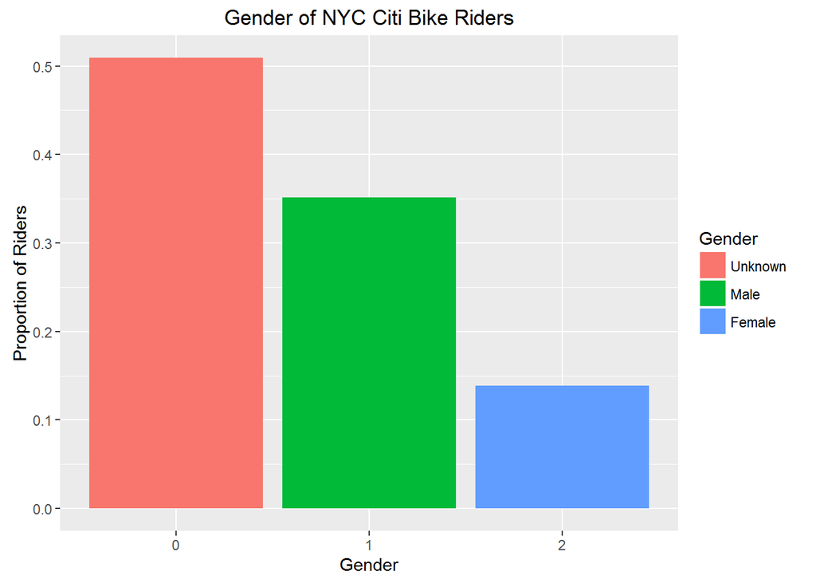

```r
ggplot(data = bike_data, aes(x = gender)) +
  geom_bar(aes(y = (..count..)/sum(..count..), fill = gender)) +
  labs(x = "Gender", y = "Proportion of Riders") +
  ggtitle("Gender of NYC Citi Bike Riders") +
  scale_fill_discrete(name = "Gender", labels = c("Unknown", "Male", "Female"))
```

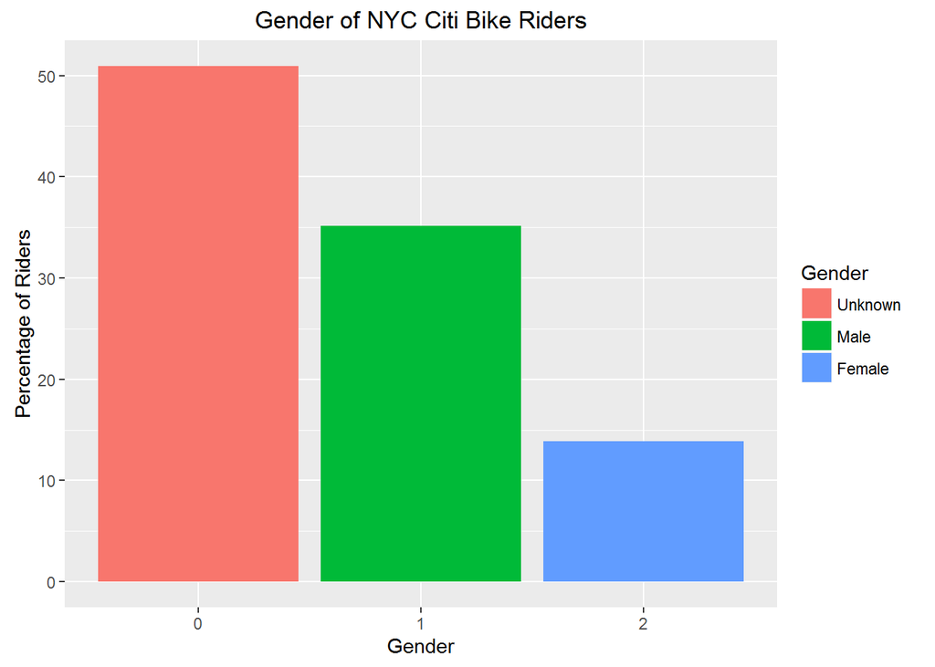

```r
ggplot(data = bike_data, aes(x = gender)) +
  geom_bar(aes(y = 100 * (..count..)/sum(..count..), fill = gender)) +
  labs(x = "Gender", y = "Percentage of Riders") +
  ggtitle("Gender of NYC Citi Bike Riders") +
  scale_fill_discrete(name = "Gender", labels = c("Unknown", "Male", "Female"))
```

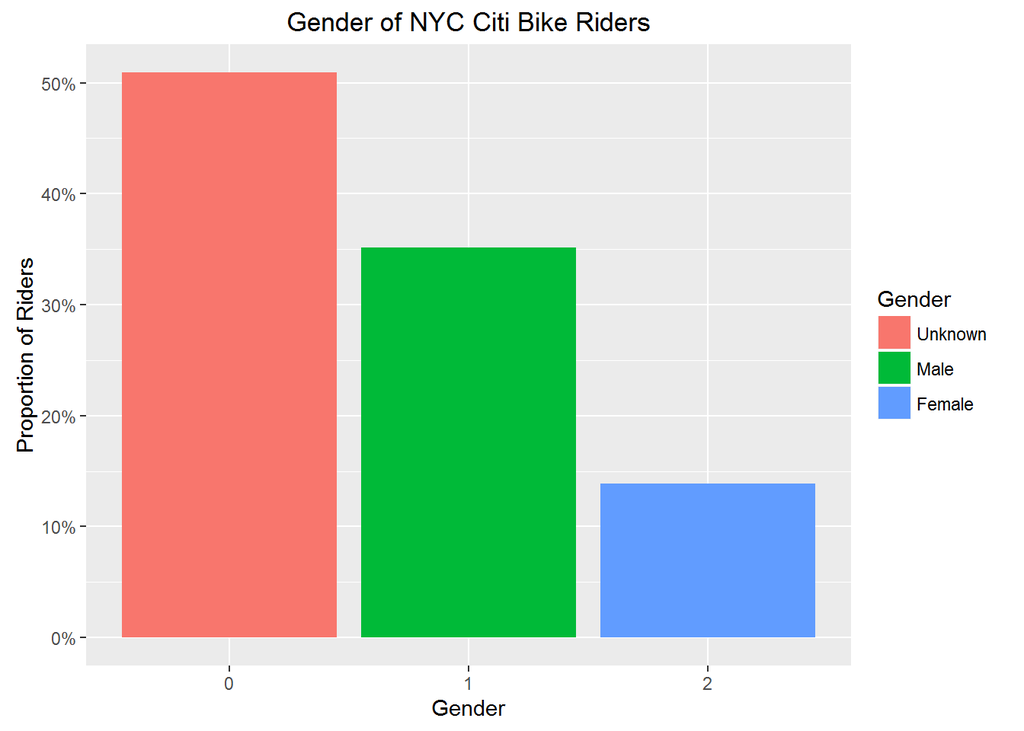

```r
library(scales)

ggplot(data = bike_data, aes(x = gender)) +
  geom_bar(aes(y = (..count..)/sum(..count..), fill = gender)) +
  scale_y_continuous(labels = percent) +
  labs(x = "Gender", y = "Proportion of Riders") +
  ggtitle("Gender of NYC Citi Bike Riders") +
  scale_fill_discrete(name = "Gender", labels = c("Unknown", "Male", "Female"))
```

# Problem 5

(12 points)

**Data Manipulation and Reordering the Bars**

```r
library(data.table)
library(dplyr)
library(ggplot2)
library(gridExtra)
airline_tweets <- fread("https://raw.githubusercontent.com/sventura/315-code-and-datasets/master/data/Tweets.csv")

#  Manipulate the airline
airline_counts <- airline_tweets %>%  #  Start with the airline_tweets data.frame
  group_by(airline) %>%  #  group by the airline variable
  summarise(count = n()) %>%  #  summarize the dataset by calculating the count of each airline
  mutate(total = sum(count))  #  add a column with the total number of flights to the result

#  The result is a new dataset that has three columns:  airline, count, and total
print(airline_counts)
```

```
## Source: local data table [6 x 3]
##
##          airline count total
##            (chr) (int) (int)
## 1 Virgin America   504 14640
## 2         United  3822 14640
## 3      Southwest  2420 14640
## 4          Delta  2222 14640
## 5     US Airways  2913 14640
## 6       American  2759 14640
```

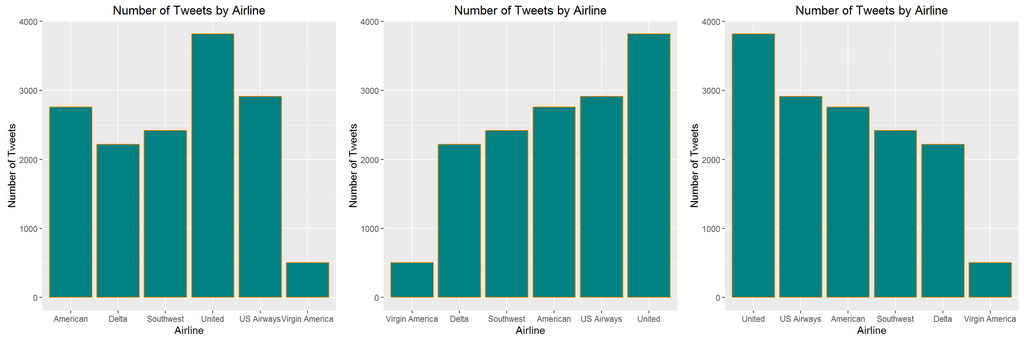

```r
#  Basic bar graph with ggplot
airline_tweet_plot <- ggplot(data = airline_counts, aes(x = airline, y = count)) +
  geom_bar(stat="identity", fill = "#008080", color = "#FF8C00") +
  ggtitle("Number of Tweets by Airline") +
  labs(x = "Airline", y = "Number of Tweets")

#  Reorder the bars in increasing order:
airline_tweet_increasing_plot <- ggplot(data = airline_counts, aes(x = reorder(airline, count), y = count)) +
  geom_bar(stat="identity", fill = "#008080", color = "#FF8C00") +
  ggtitle("Number of Tweets by Airline") +
  labs(x = "Airline", y = "Number of Tweets")

#  Reorder the bars in increasing order:
#  Note: We will learn more about piping [%>%] throughout the course.
#  There are multiple ways to accomplish this
airline_tweet_decreasing_plot <- ggplot(data = airline_counts, aes(x = reorder(airline, count %>% (function(x) return(-x))), y = count)) +
  geom_bar(stat="identity", fill = "#008080", color = "#FF8C00") +
  ggtitle("Number of Tweets by Airline") +
  labs(x = "Airline", y = "Number of Tweets")

#  Plot all 3
grid.arrange(airline_tweet_plot, airline_tweet_increasing_plot, airline_tweet_decreasing_plot, nrow = 1)
```

# Problem 6

(4 points each)

**More Data Manipulation and Incorporating Statistical Information Into Graphs**

Using the same set-up as Problem 5, we’ll add some additional information to `airline_counts`:

```r
#  Add the following information to the airline_counts dataset:
#    Proportions and percentages corresponding to each category
#    The standard error on the proportios or percentages corresponding to each category
#    Lower bound of an (approximate) 95% confidence interval around the true proportion in each category
#    Upper bound of an (approximate) 95% confidence interval around the true proportion in each category
airline_counts <- mutate(airline_counts,
                         proportion = count / total,
                         percentage = proportion * 100,
                         std_error = 87,
                         lower = proportion - 1.96 * std_error,
                         upper = proportion + 1.96 * std_error)

print(airline_counts)
```

```
## Source: local data table [6 x 8]
##
##          airline count total proportion percentage std_error     lower
##            (chr) (int) (int)      (dbl)      (dbl)     (dbl)     (dbl)
## 1 Virgin America   504 14640 0.03442623   3.442623        87 -170.4856
## 2         United  3822 14640 0.26106557  26.106557        87 -170.2589
## 3      Southwest  2420 14640 0.16530055  16.530055        87 -170.3547
## 4          Delta  2222 14640 0.15177596  15.177596        87 -170.3682
## 5     US Airways  2913 14640 0.19897541  19.897541        87 -170.3210
## 6       American  2759 14640 0.18845628  18.845628        87 -170.3315
## Variables not shown: upper (dbl)
```

```r
airline_counts <- mutate(airline_counts,
                         proportion = count / total,
                         percentage = proportion * 100,
                         std_error =  sqrt(proportion * (1 - proportion)
                                           / total),
                         lower = proportion - 1.96 * std_error,
                         upper = proportion + 1.96 * std_error)

print(airline_counts)
```

```
## Source: local data table [6 x 8]
##
##          airline count total proportion percentage   std_error      lower
##            (chr) (int) (int)      (dbl)      (dbl)       (dbl)      (dbl)
## 1 Virgin America   504 14640 0.03442623   3.442623 0.001506839 0.03147282
## 2         United  3822 14640 0.26106557  26.106557 0.003630005 0.25395076
## 3      Southwest  2420 14640 0.16530055  16.530055 0.003069953 0.15928344
## 4          Delta  2222 14640 0.15177596  15.177596 0.002965420 0.14596373
## 5     US Airways  2913 14640 0.19897541  19.897541 0.003299530 0.19250833
## 6       American  2759 14640 0.18845628  18.845628 0.003232144 0.18212128
## Variables not shown: upper (dbl)
```

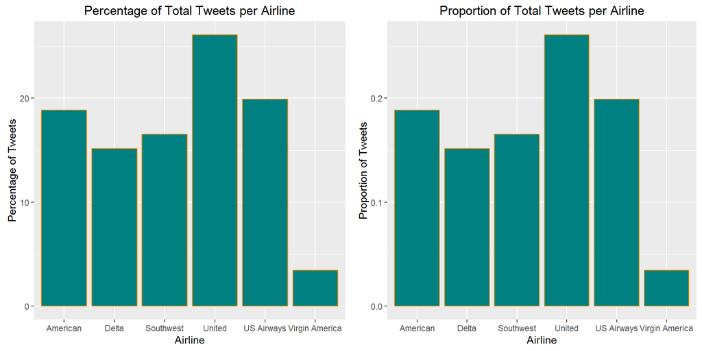

```r
#  Bar graph of percentages
airline_percentage_plot <- ggplot(data = airline_counts, aes(x = airline, y = percentage)) +
  geom_bar(stat="identity", fill = "#008080", color = "#FF8C00") +
  ggtitle("Percentage of Total Tweets per Airline") +
  labs(x = "Airline", y = "Percentage of Tweets")

#  Bar graph of proportions
airline_proportion_plot <- ggplot(data = airline_counts, aes(x = airline, y = proportion)) +
  geom_bar(stat="identity", fill = "#008080", color = "#FF8C00") +
  ggtitle("Proportion of Total Tweets per Airline") +
  labs(x = "Airline", y = "Proportion of Tweets")

grid.arrange(airline_percentage_plot, airline_proportion_plot, nrow = 1)
```

The difference between these two graphs is the variable plotted on the y-axis of the plot, which changes its scale. The one on the left shows the percentage of tweets that each airline was mentioned in, out of 100, while the one on the right shows the proportion of tweets that each airline was mentioned in, out of 1.

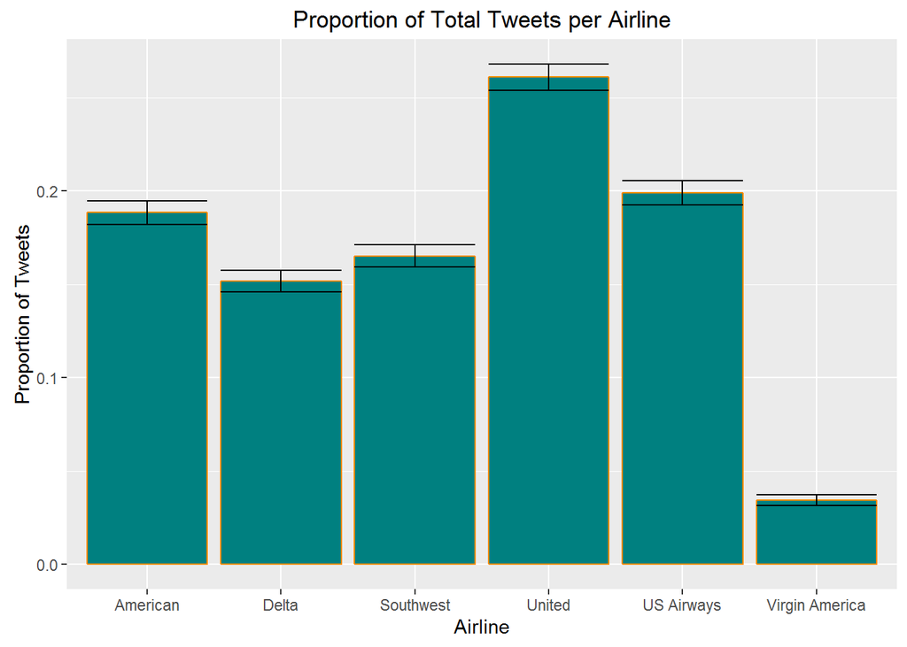

```r
airline_proportion_error_plot <- ggplot(data = airline_counts, aes(x = airline, y = proportion)) +
  geom_bar(stat="identity", fill = "#008080", color = "#FF8C00") +
  ggtitle("Proportion of Total Tweets per Airline") +
  labs(x = "Airline", y = "Proportion of Tweets") +
  geom_errorbar(aes(ymin = lower, ymax = upper))

airline_proportion_error_plot
```

The 95% confidence intervals of the proportion of tweets about US Airways and American Airlines intersect (as can be confirmed by looking at the data frame.) Thus, there is not a statistically significant difference between the proportions of tweets about American and US Airways.

# Problem 7

(3 points each)

**Even More Data Manipulation with the NYC Citi Bike Data**

```r
library(reshape2)
date_time <- colsplit(bike_data$starttime, " ", c("date", "time"))
bike_data <- mutate(bike_data,
                    birth_decade = paste0(substr(`birth year`, 1, 3), "0s"),
                    date = as.vector(date_time$date),
                    time_of_day = as.vector(date_time$time),
                    hour_of_day = substr(time_of_day, 1, 2),
                    am_or_pm = ifelse(as.integer(hour_of_day) < 12, "AM", "PM"),
                    day_of_week = weekdays(as.Date(date, format = "%m/%d/%Y")),
                    less_than_30_mins = ifelse(tripduration < 1800,
                                               "Short Trip", "Long Trip"),
                    weekend = ifelse(day_of_week %in% c("Saturday", "Sunday"),
                                     "Weekend", "Weekday"))
```

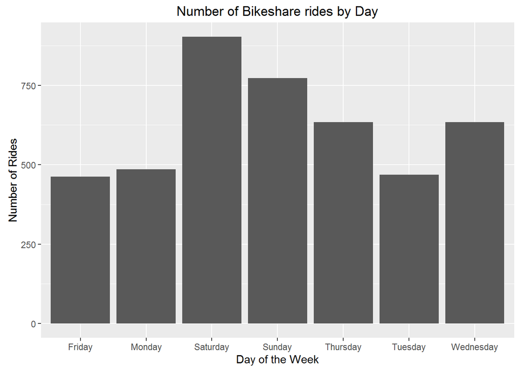

```r
ggplot(bike_data, aes(x = day_of_week)) +
  geom_bar() +
  labs(x = "Day of the Week", y = "Number of Rides",
       title = "Number of Bikeshare rides by Day")
```

The days are not displayed in the order we would expect

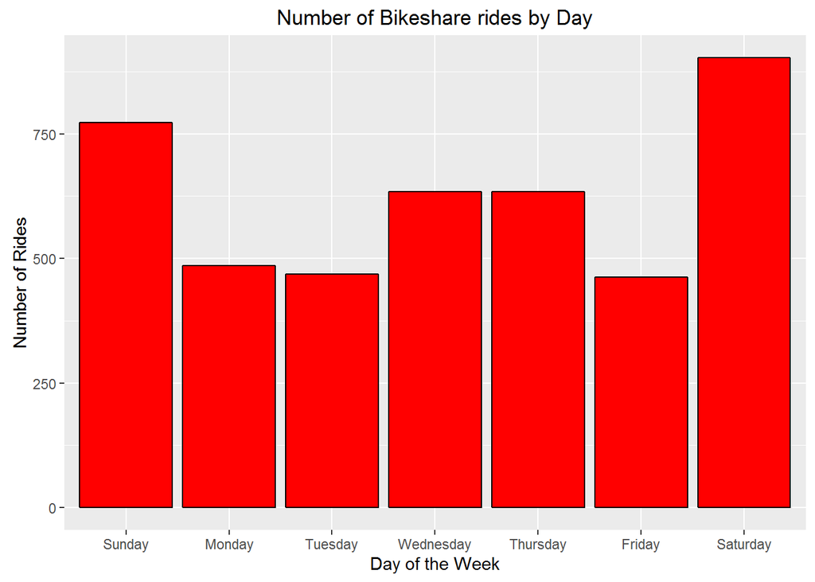

```r
bike_data$day_of_week <-
  factor(bike_data$day_of_week,
         levels= c("Sunday", "Monday", "Tuesday", "Wednesday", "Thursday", "Friday", "Saturday"))

ggplot(bike_data, aes(x = day_of_week)) +
  geom_bar(fill = "red", color = "black") +
  labs(x = "Day of the Week", y = "Number of Rides",
       title = "Number of Bikeshare rides by Day")
```

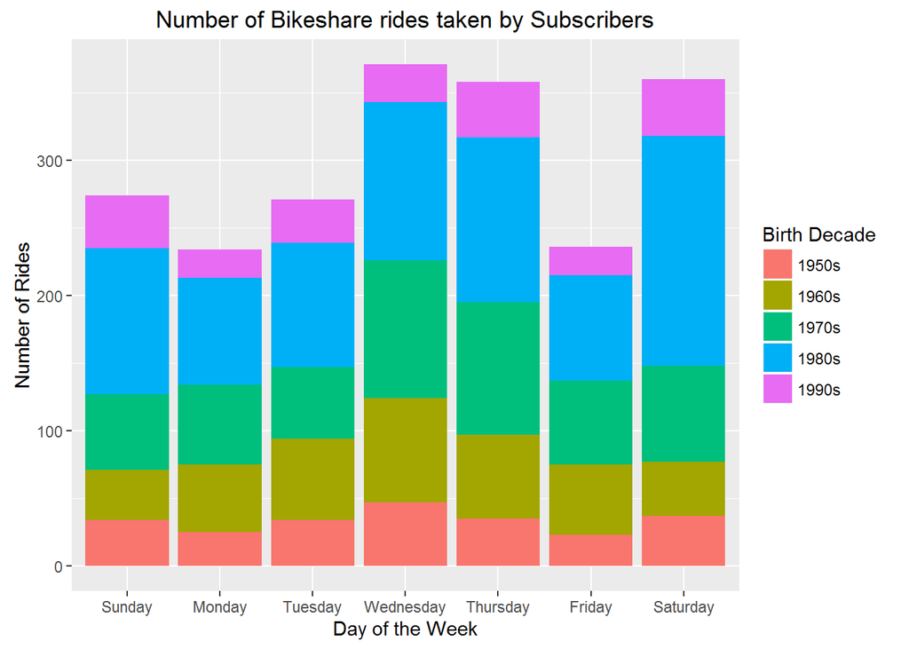

```r
bike_data_subset <- filter(bike_data,
                        usertype != "Customer",
                        `birth year` >= 1950)

ggplot(bike_data_subset, aes(x = day_of_week)) +
  geom_bar(aes(fill = birth_decade)) +
  labs(x = "Day of the Week", y = "Number of Rides", fill = "Birth Decade",
       title = "Number of Bikeshare rides taken by Subscribers")
```

4. We note that it is no longer the case that there are more rides taken on weekend days. This suggests that the behavior of Customers and Subscribers to the bike share service follow different behavioral patterns.

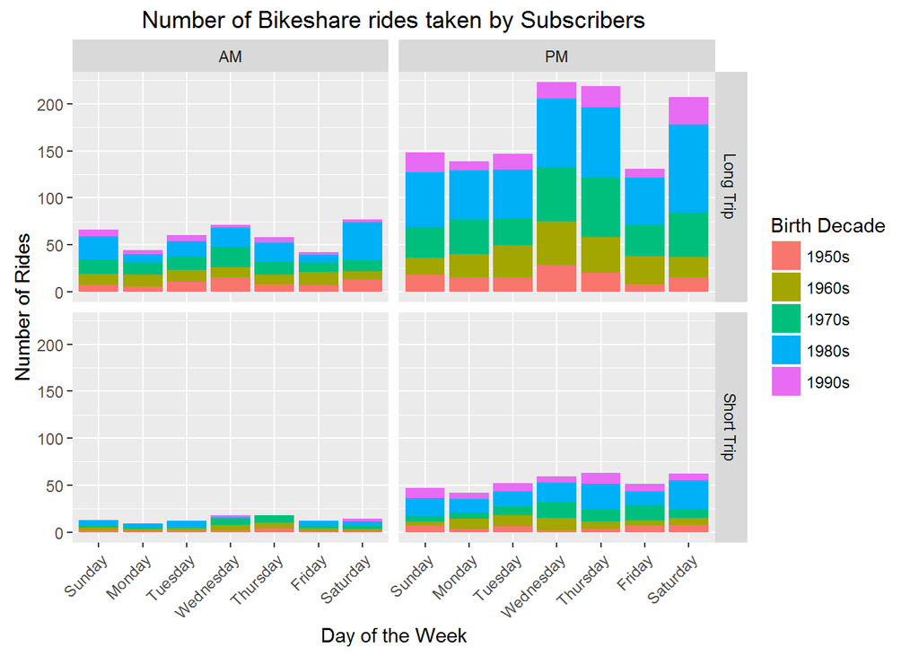

```r
bike_data_subset <- filter(bike_data,
                        usertype != "Customer",
                        `birth year` >= 1950)

ggplot(bike_data_subset, aes(x = day_of_week)) +
  geom_bar(aes(fill = birth_decade)) +
  labs(x = "Day of the Week", y = "Number of Rides",
       title = "Number of Bikeshare rides taken by Subscribers") +
  facet_grid(less_than_30_mins~am_or_pm) +
  theme(axis.text.x = element_text(angle = 45, hjust = 1)) +
  scale_fill_discrete(guide = guide_legend(title = "Birth Decade"))
```

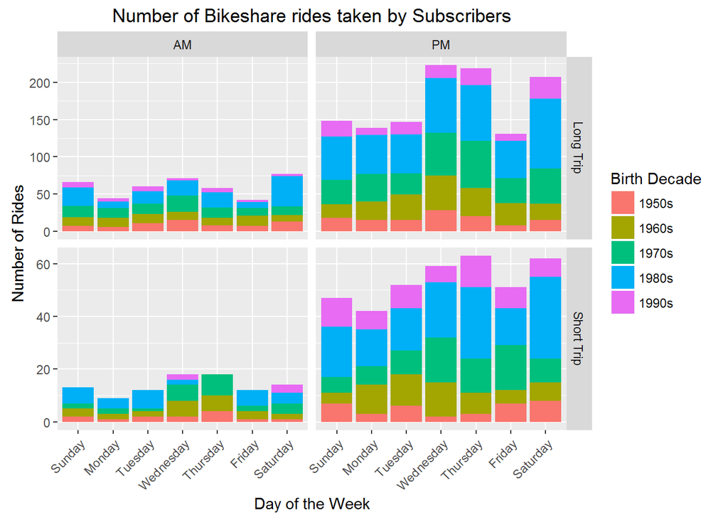

```r
bike_data_subset <- filter(bike_data,
                        usertype != "Customer",
                        `birth year` >= 1950)

ggplot(bike_data_subset, aes(x = day_of_week)) +
  geom_bar(aes(fill = birth_decade)) +
  labs(x = "Day of the Week", y = "Number of Rides",
       title = "Number of Bikeshare rides taken by Subscribers") +
  facet_grid(less_than_30_mins~am_or_pm, scale = "free_y") +
  theme(axis.text.x = element_text(angle = 45, hjust = 1)) +
  scale_fill_discrete(guide = guide_legend(title = "Birth Decade"))
```

Differences we noted previously are now more apparent than they were previously. Unfortunately, it is now substantially more difficult to compare the number of observations in bars across the facets (or visually estimate the total number of observations within a facet).

7. (We did this in the previous part – see the code above!)

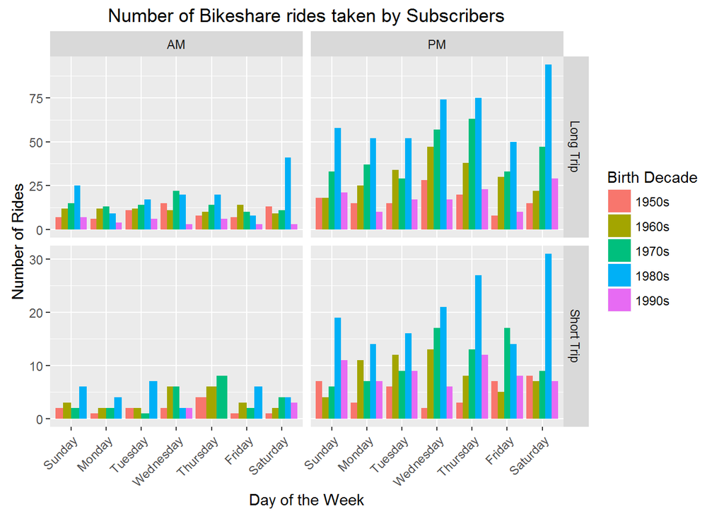

```r
bike_data_subset <- filter(bike_data,
                        usertype != "Customer",
                        `birth year` >= 1950)

ggplot(bike_data_subset, aes(x = day_of_week)) +
  geom_bar(aes(fill = birth_decade), position="dodge") +
  labs(x = "Day of the Week", y = "Number of Rides",
       title = "Number of Bikeshare rides taken by Subscribers") +
  facet_grid(less_than_30_mins~am_or_pm, scale = "free_y") +
  theme(axis.text.x = element_text(angle = 45, hjust = 1)) +
  scale_fill_discrete(guide = guide_legend(title = "Birth Decade"))
```

The y-limits get smaller because they now only need to be large enough to show the largest single category.

# Problem 8

(3 points each)

```r
library(data.table)
library(dplyr)
library(reshape2)
tweets_sub <- filter(airline_tweets,
                     user_timezone %in% c("Mountain Time (US & Canada)",
                                          "Pacific Time (US & Canada)",
                                          "Central Time (US & Canada)",
                                          "Eastern Time (US & Canada)"))

temp <- colsplit(as.vector(tweets_sub$user_timezone), " ", c("first_word", "extra_word"))
tweets_sub <- mutate(tweets_sub, user_timezone = temp$first_word)
```

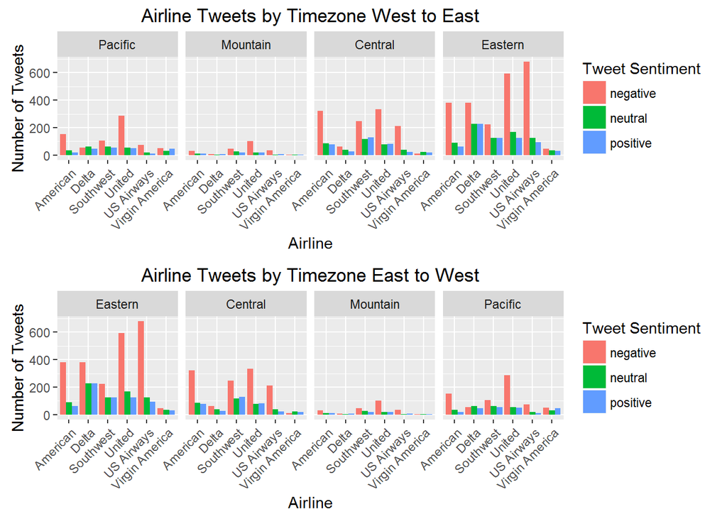

```r
tweets_sub <- mutate(tweets_sub,
                     user_timezone_we = factor(user_timezone,
                                               levels = c("Pacific", "Mountain", "Central", "Eastern")),
                     user_timezone_ew = factor(user_timezone,
                                               levels = rev(levels(user_timezone_we))))

p.west.east <- ggplot(tweets_sub, aes(x = airline)) +
  geom_bar(aes(fill = airline_sentiment), position="dodge") +
  facet_grid(.~user_timezone_we) +
  theme(axis.text.x = element_text(angle = 45, hjust = 1)) +
  scale_fill_discrete(guide = guide_legend(title = "Tweet Sentiment")) +
  labs(x = "Airline", y = "Number of Tweets",
       title = "Airline Tweets by Timezone West to East")

p.east.west <- ggplot(tweets_sub, aes(x = airline)) +
  geom_bar(aes(fill = airline_sentiment), position="dodge") +
  facet_grid(.~user_timezone_ew) +
  theme(axis.text.x = element_text(angle = 45, hjust = 1)) +
  scale_fill_discrete(guide = guide_legend(title = "Tweet Sentiment")) +
  labs(x = "Airline", y = "Number of Tweets",
       title = "Airline Tweets by Timezone East to West")

grid.arrange(p.west.east, p.east.west, ncol = 1)
```

I prefer the graph that goes from west to east as it is consistent with the way maps of the US are typically displayed. That said, one could make an argument for the east-to-west graph, since this corresponds to the direction the sun moves (that is, mornings occur in the east first since the west is three hours behind).

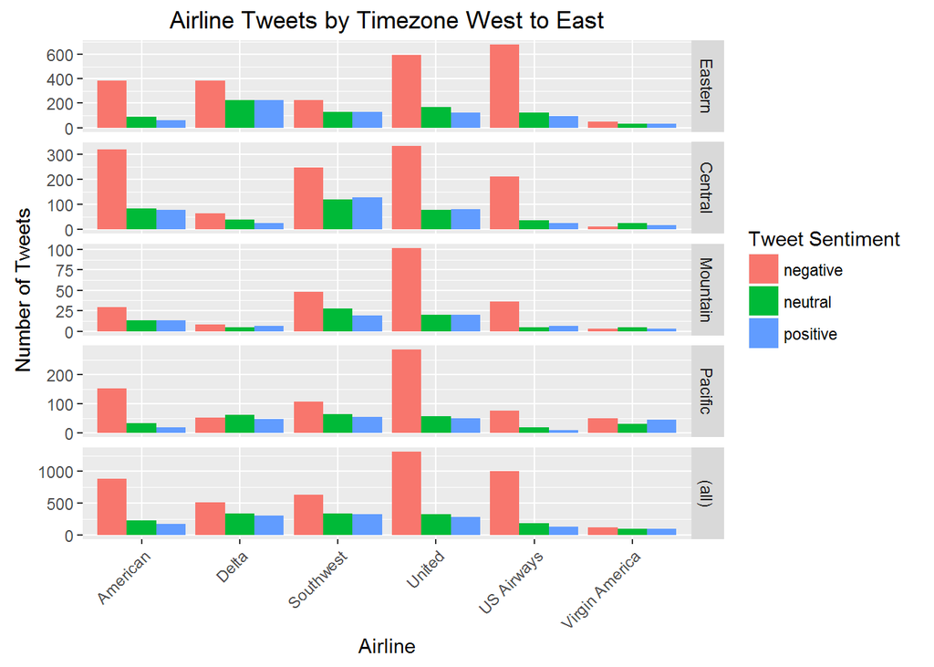

```r
ggplot(tweets_sub, aes(x = airline)) +
  geom_bar(aes(fill = airline_sentiment), position="dodge") +
  facet_grid(user_timezone_we ~ ., margins = TRUE, scales = "free_y", as.table = FALSE) +
  theme(axis.text.x = element_text(angle = 45, hjust = 1)) +
  scale_fill_discrete(guide = guide_legend(title = "Tweet Sentiment")) +
  labs(x = "Airline", y = "Number of Tweets",
       title = "Airline Tweets by Timezone West to East")
```

It is easier to compare the marginal distributions if we switch to a column of graphs allowing the scales to adjust more. In many cases the marginal distributions do not closely match the overall distribution. For example US Airways has a much greater share in the Eastern timezone, and an offsetting smaller share in the Pacific and Mountain timezones than it does overall. We can see a similar pattern for Delta. In contrast American has a larger share of the tweets in the Central timezone than it does in the other timezones or the overall distribution.